# R Text Mining with Quanteda & Tidytext

## Sentiment Analysis with Tidytext

Reference: [Text Mining with R](https://www.tidytextmining.com/sentiment.html).

Sentiment analysis is an interesting way to learn more about your data. There are different ways to analyze sentiments. Today, we are going to discuss the easiest one - dictionary-based sentiment analysis.

The tidytext package has some built-in sentiment dictionaries, including [AFINN](http://www2.imm.dtu.dk/pubdb/pubs/6010-full.html), [Bing](https://www.cs.uic.edu/~liub/FBS/sentiment-analysis.html), and [NRC](http://saifmohammad.com/WebPages/NRC-Emotion-Lexicon.htm). Let’s have a look!  
**Note that all the three dictionaries are unigram, meaning that they only consider the sentiment of single words. “not good” will have the same sentiment score as “good”**.

To use these dictionaries, we must first tokenize our texts in a dataframe.

```r
# Using tidytext's unnest_tokens() function to unnest words in df's Body column into a column called "word"
df_tokens <- df %>% unnest_tokens(word, Body)
```

### AFINN

The AFINN lexicon assigns words with a score that runs between -5 and 5, with negative scores indicating negative sentiment and positive scores indicating positive sentiment.  
Let’s take a look!

```r
get_sentiments("afinn")
```

| word | value |
| --- | --- |
| abandon | -2 |
| abandoned | -2 |
| abandons | -2 |
| abducted | -2 |
| abduction | -2 |
| abductions | -2 |
| abhor | -3 |
| abhorred | -3 |
| abhorrent | -3 |
| abhors | -3 |

[output cut: 2467 more lines]

Now let’s try to use this dictionary!

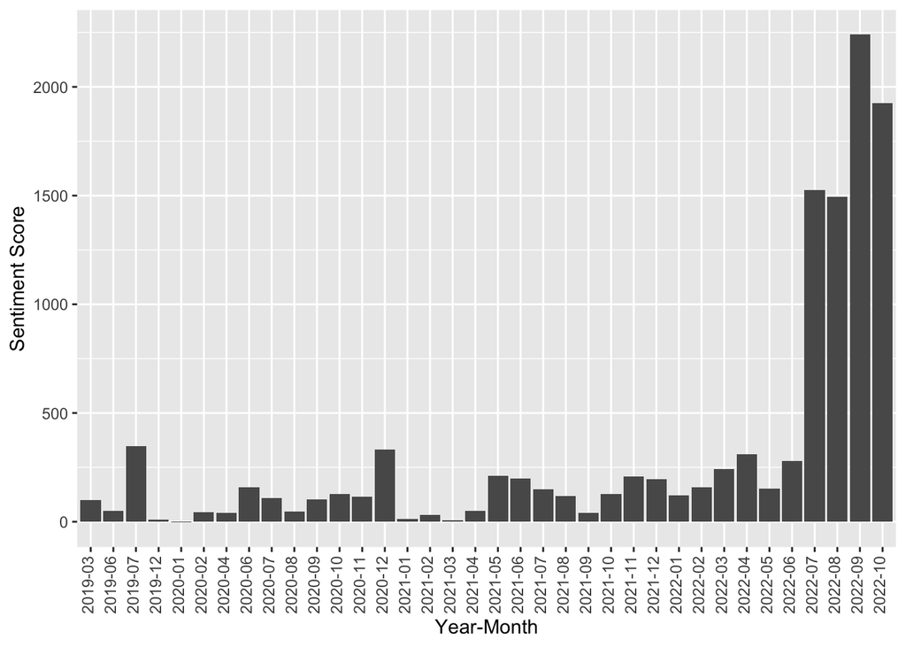

```r
afinn <- get_sentiments("afinn") # put the dictionary into a data frame

# matching every word that exists in both our news data frame and the afinn dictionary
df_afinn <- df_tokens %>% inner_join(afinn, by = "word")


afinn_sentiment_by_month <- df_afinn %>%
  group_by(year_month) %>% # grouping words by month
  summarise(sentiment = sum(value)) # for each month, summing up the values of all its words

ggplot(afinn_sentiment_by_month, aes(x = year_month, y = sentiment)) +
  geom_col() +
  theme(axis.text.x = element_text(angle = 90, hjust = 1, vjust = 0.25)) +
  xlab("Year-Month") +
  ylab("Sentiment Score")
```

Yay! It worked!!! But wait… Isn’t the graph a bit familiar? Well, it seems that we get higher sentiment score in the later months just because we have more articles (and therefore, more tokens) in those months… To put things into perspective, we need to calculate the sentiment score in proportion to the total number of tokens.

Let’s try one more time!

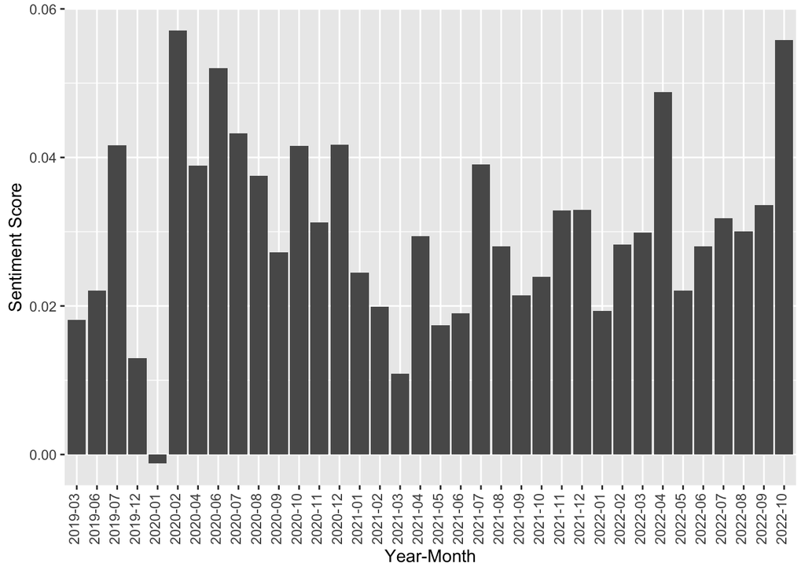

```r
# Do you remember the month_total dataframe we made to calculate our keywords' occurrence rate?

month_total <- corp_sum %>% # taking the old corpus summary data frame
  group_by(year_month) %>% # grouping entries by the year_month variable
  summarize(total = sum(Tokens))
  # for each group, sum up the token numbers of all entries,
  # and record the sum into the total column


# Adding each month's total token number to the sentiment_by_month data frame
afinn_sentiment_by_month <- afinn_sentiment_by_month %>%
  inner_join(month_total, by = "year_month")
afinn_sentiment_by_month$rate <- afinn_sentiment_by_month$sentiment/afinn_sentiment_by_month$total

ggplot(afinn_sentiment_by_month, aes(x = year_month, y = rate)) +
  geom_col() +
  theme(axis.text.x = element_text(angle = 90, hjust = 1, vjust = 0.25)) +
  xlab("Year-Month") +
  ylab("Sentiment Score")
```

Now it looks much nicer! Let’s proceed to the next dictionary!

### Bing

The Bing lexicon categorizes words in a binary fashion into positive and negative categories.

```r
get_sentiments("bing")
```

| word | sentiment |
| --- | --- |
| 2-faces | negative |
| abnormal | negative |
| abolish | negative |
| abominable | negative |
| abominably | negative |
| abominate | negative |
| abomination | negative |
| abort | negative |
| aborted | negative |
| aborts | negative |

[output cut: 6776 more lines]

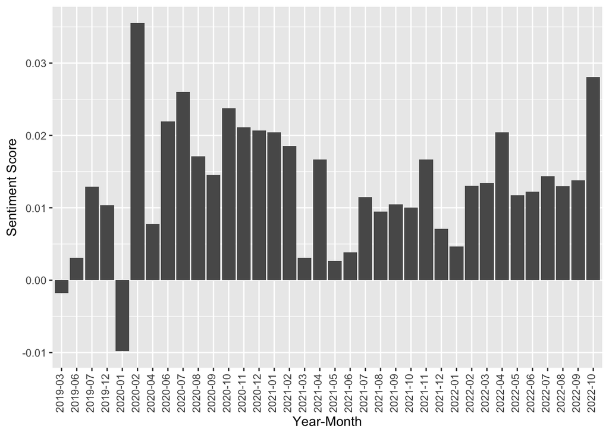

```r
bing <- get_sentiments("bing") # put the dictionary into a data frame

# matching every word that exists in both our news data frame and the bing dictionary
df_bing <- df_tokens %>% inner_join(bing, by = "word")


bing_sentiment_by_month <- df_bing %>%
  group_by(year_month) %>% # grouping the words based on months
  count(sentiment) %>% # count the positive and negative words for each month
  pivot_wider(names_from = sentiment, values_from = n) # put positive and negative counts into different columns

# calculating each month's overall sentiment score by minus the negative score from the positive score
bing_sentiment_by_month$sentiment <- bing_sentiment_by_month$positive - bing_sentiment_by_month$negative

# Adding each month's total token number to the sentiment_by_month data frame
bing_sentiment_by_month <- bing_sentiment_by_month %>%
  inner_join(month_total, by = "year_month")
bing_sentiment_by_month$rate <- bing_sentiment_by_month$sentiment/bing_sentiment_by_month$total


ggplot(bing_sentiment_by_month, aes(x = year_month, y = rate)) +
  geom_col() +
  theme(axis.text.x = element_text(angle = 90, hjust = 1, vjust = 0.25)) +
  xlab("Year-Month") +
  ylab("Sentiment Score")
```

### NRC

nrc: The nrc lexicon categorizes words into one or more categories of positive, negative, anger, anticipation, disgust, fear, joy, sadness, surprise, and trust.

```r
get_sentiments("nrc")
```

| word | sentiment |
| --- | --- |
| abacus | trust |
| abandon | fear |
| abandon | negative |
| abandon | sadness |
| abandoned | anger |
| abandoned | fear |
| abandoned | negative |
| abandoned | sadness |
| abandonment | anger |
| abandonment | fear |

[output cut: 9990 more lines]

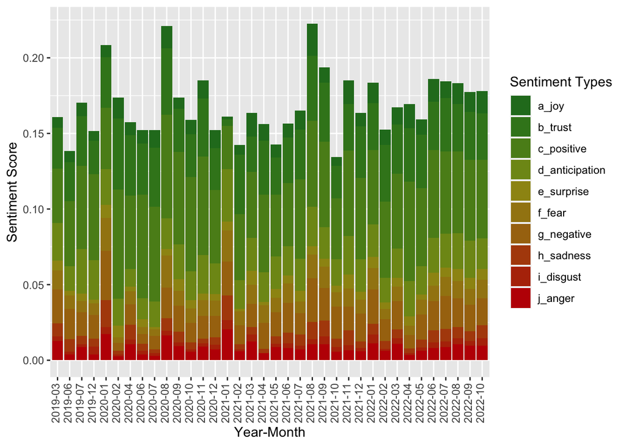

```r
nrc <- get_sentiments("nrc") # put the dictionary into a data frame

# matching every word that exists in both our news data frame and the nrc dictionary
df_nrc <- df_tokens %>% inner_join(nrc, by = "word")

df_nrc <- dummy_cols(df_nrc, select_columns = "sentiment")
# using the dummy_cols() function from the "fastDummies" package to create dummy variables based on the sentiment column

nrc_sentiment_by_month <- df_nrc %>%
  group_by(year_month) %>% # grouping the words based on months
  # For each month, summing up the occurrences of words that are positive, negative, etc.
  # I ranked them according to my own subjective feeling of their positiveness and negativeness
  summarize(a_joy = sum(sentiment_joy),
            b_trust = sum(sentiment_trust),
            c_positive = sum(sentiment_positive),
            d_anticipation = sum(sentiment_anticipation),
            e_surprise = sum(sentiment_surprise),
            f_fear = sum(sentiment_fear),
            g_negative = sum(sentiment_negative),
            h_sadness = sum(sentiment_sadness),
            i_disgust = sum(sentiment_disgust),
            j_anger = sum(sentiment_anger))

# Adding each month's total token number to the sentiment_by_month data frame
nrc_sentiment_by_month <- nrc_sentiment_by_month %>% inner_join(month_total, by = "year_month")

# Divide each sentiment score by the total number of tokens
nrc_sentiment_by_month[,2:11] <- nrc_sentiment_by_month[,2:11]/nrc_sentiment_by_month$total

nrc_sentiment_by_month %>%
  # regarding each cell (except those in the year_month and total columns) as a key-value pair,
  # with the key being its column name (sentiment type) and the value being its value
  gather(key, value, -c(year_month, total)) %>%

  # plotting year_month on the x-axis, and the value of each sentiment type in that month on the y-axis
  ggplot(aes(x = year_month, y = value)) +

  # coloring the bars based on the sentiment category
  geom_col(aes(fill = key)) +

  # customizing a color scheme for different sentiments
  scale_fill_manual(values = c("a_joy" = "#257A24",
                               "b_trust" = "#3C8321",
                               "c_positive" = "#5A8C1E",
                               "d_anticipation" = "#7E951A",
                               "e_surprise" = "#9E9315",
                               "f_fear" = "#A38413",
                               "g_negative" = "#A87310",
                               "h_sadness" = "#B14A0A",
                               "i_disgust" = "#B53307",
                               "j_anger" = "#BF0003")) +
  theme(axis.text.x = element_text(angle = 90, hjust = 1, vjust = 0.25)) +
  xlab("Year-Month") +
  ylab("Sentiment Score") +
  labs(fill = "Sentiment Types")
```

What if I want to see different outlets’ sentiments?

```r
nrc_sentiment_by_month_source <- df_nrc %>%
  group_by(year_month, Source) %>% # grouping the words based on months and sources

  # For each month-Source pair, summing up the occurrences of words that are positive, negative, etc.
  # I ranked them according to my own subjective feeling of their positiveness and negativeness
  summarize(a_joy = sum(sentiment_joy),
            b_trust = sum(sentiment_trust),
            c_positive = sum(sentiment_positive),
            d_anticipation = sum(sentiment_anticipation),
            e_surprise = sum(sentiment_surprise),
            f_fear = sum(sentiment_fear),
            g_negative = sum(sentiment_negative),
            h_sadness = sum(sentiment_sadness),
            i_disgust = sum(sentiment_disgust),
            j_anger = sum(sentiment_anger))
month_source <- corp_sum %>% # taking the old corpus summary data frame
  group_by(year_month, Source) %>% # grouping entries by the year_month and source variables
  summarize(total = sum(Tokens))
```

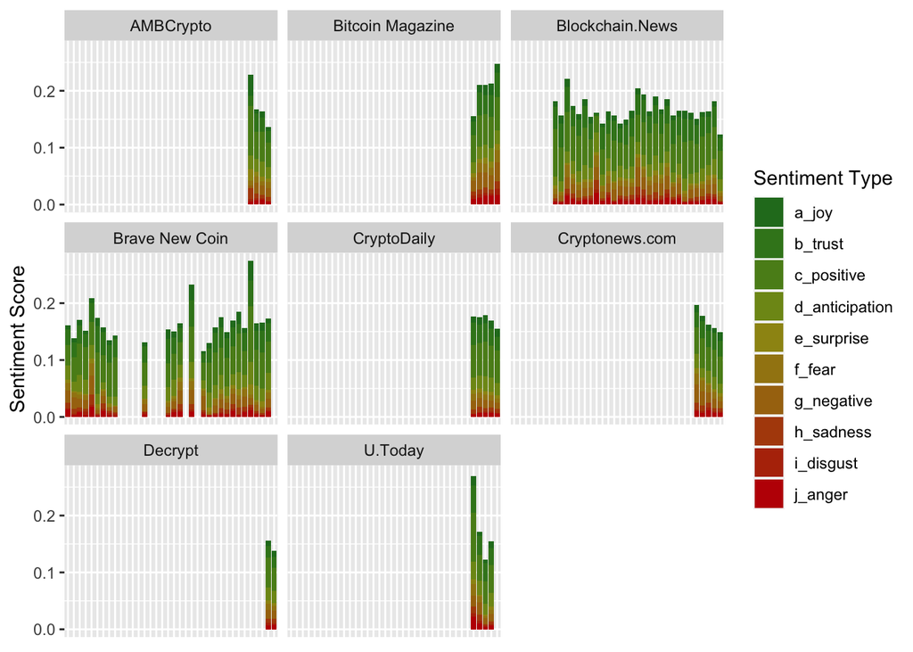

```r
  # for each group, sum up the token numbers of all entries,
  # and record the sum into the total column

nrc_sentiment_by_month_source <- nrc_sentiment_by_month_source %>%
  inner_join(month_source, by = c("year_month", "Source"))

# Divide each sentiment score by the total number of tokens
nrc_sentiment_by_month_source[,3:12] <- nrc_sentiment_by_month_source[,3:12]/nrc_sentiment_by_month_source$total



nrc_sentiment_by_month_source %>%

  # regarding each cell (except those in the year_month and Source columns) as a key-value pair,
  # with the key being its column name (sentiment type) and the value being its value
  gather(key, value, -c(year_month, Source, total)) %>%

  # plotting year_month on the x-axis, and the value of each sentiment type in that month on the y-axis
  ggplot(aes(x = year_month, y = value)) +

  # coloring the bars based on the sentiment category
  geom_col(aes(fill = key)) +

  # present each source in one facet, make three rows of facets
  facet_wrap(~Source, nrow = 3) +

  # customizing a color scheme for different sentiments
  scale_fill_manual(values = c("a_joy" = "#257A24",
                               "b_trust" = "#3C8321",
                               "c_positive" = "#5A8C1E",
                               "d_anticipation" = "#7E951A",
                               "e_surprise" = "#9E9315",
                               "f_fear" = "#A38413",
                               "g_negative" = "#A87310",
                               "h_sadness" = "#B14A0A",
                               "i_disgust" = "#B53307",
                               "j_anger" = "#BF0003")) +
  xlab("Year-Month") +
  ylab("Sentiment Score") +
  labs(fill = "Sentiment Type") +

  # getting rid of x-axis ticks, texts, and label for a pleasing visualization
  theme(axis.title.x=element_blank(),
        axis.text.x=element_blank(),
        axis.ticks.x=element_blank())
```

### Comparing Sentiment Dictionaries

```r
head(afinn_sentiment_by_month)
```

| year_month | sentiment | total | rate |
| --- | --- | --- | --- |
| 2019-03 | 100 | 5529 | 0.018086453 |
| 2019-06 | 50 | 2269 | 0.022036139 |
| 2019-07 | 348 | 8358 | 0.041636755 |
| 2019-12 | 10 | 772 | 0.012953368 |
| 2020-01 | -4 | 3254 | -0.001229256 |
| 2020-02 | 45 | 788 | 0.057106599 |

```r
head(bing_sentiment_by_month)
```

| year_month | negative | positive | sentiment | total | rate |
| --- | --- | --- | --- | --- | --- |
| 2019-03 | 117 | 107 | -10 | 5529 | -0.001808645 |
| 2019-06 | 51 | 58 | 7 | 2269 | 0.003085059 |
| 2019-07 | 148 | 256 | 108 | 8358 | 0.012921752 |
| 2019-12 | 16 | 24 | 8 | 772 | 0.010362694 |
| 2020-01 | 102 | 70 | -32 | 3254 | -0.009834050 |
| 2020-02 | 3 | 31 | 28 | 788 | 0.035532995 |

```r
head(nrc_sentiment_by_month)
```

| year_month | a_joy | b_trust | c_positive | d_anticipation | e_surprise | f_fear | g_negative | h_sadness | i_disgust | j_anger | total |
| --- | --- | --- | --- | --- | --- | --- | --- | --- | --- | --- | --- |
| 2019-03 | 0.007053717 | 0.02694882 | 0.03599204 | 0.02495931 | 0.006330259 | 0.012660517 | 0.022427202 | 0.008500633 | 0.003074697 | 0.012841382 | 5529 |
| 2019-06 | 0.007492287 | 0.02556192 | 0.04319083 | 0.01630674 | 0.003085059 | 0.008814456 | 0.019832525 | 0.008373733 | 0.001762891 | 0.003966505 | 2269 |
| 2019-07 | 0.009093084 | 0.03278296 | 0.05479780 | 0.02967217 | 0.005025126 | 0.007178751 | 0.015793252 | 0.005503709 | 0.001914334 | 0.008614501 | 8358 |
| 2019-12 | 0.006476684 | 0.02202073 | 0.05699482 | 0.02590674 | 0.002590674 | 0.007772021 | 0.015544041 | 0.005181347 | 0.005181347 | 0.003886010 | 772 |
| 2020-01 | 0.007990166 | 0.03349723 | 0.04056546 | 0.02366318 | 0.008604794 | 0.021819299 | 0.032575292 | 0.017824216 | 0.004609711 | 0.017209588 | 3254 |
| 2020-02 | 0.013959391 | 0.04695431 | 0.07233503 | 0.01776650 | 0.007614213 | 0.003807107 | 0.005076142 | 0.002538071 | 0.001269036 | 0.002538071 | 788 |

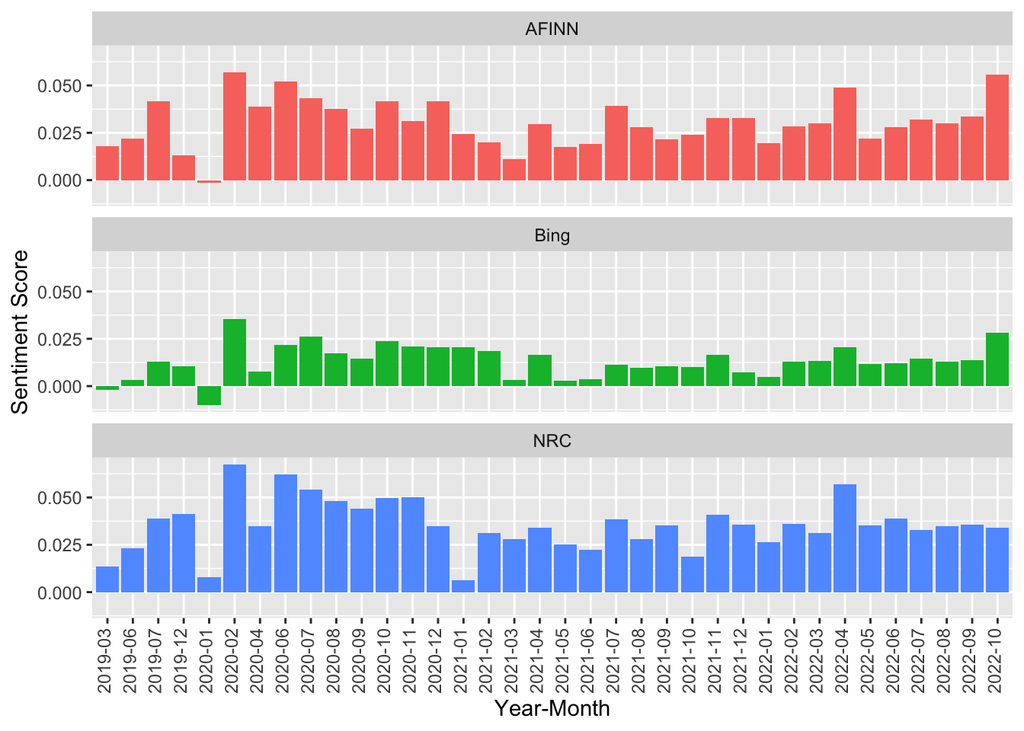

```r
# calculating each month's overall nrc sentiment score by minus the negative score from the positive score
nrc_sentiment_by_month$rate = nrc_sentiment_by_month$c_positive - nrc_sentiment_by_month$g_negative

# processing each dataframe by adding a dictionary column to note down the respective dictionary, and
# getting rid of unnecessary columns
afinn_sentiment <- afinn_sentiment_by_month[c("year_month", "rate")] %>% mutate(dict = "AFINN")
bing_sentiment <- bing_sentiment_by_month[c("year_month", "rate")] %>% mutate(dict = "Bing")
nrc_sentiment <- nrc_sentiment_by_month[c("year_month", "rate")] %>% mutate(dict = "NRC")

# combining the three data frames
sentiment_compare <- rbind(afinn_sentiment, bing_sentiment, nrc_sentiment)

ggplot(sentiment_compare, aes(x = year_month, y = rate, fill = dict)) +
  geom_col(show.legend = FALSE) +
  facet_wrap(~ dict, ncol = 1) +
  theme(axis.text.x = element_text(angle = 90, hjust = 1, vjust = 0.25)) +
  xlab("Year-Month") +
  ylab("Sentiment Score") +
  labs(fill = "Sentiment Dictionaries")
```